# Sum of Natural Number

## Sum of Natural Number

That is ti get the sum of the following:

sum = $1+2+3+4+5+7+...$

Let see of we can write a recursive definition for this:

$sum(n) = 1+2+3+4+5+7+...+n$

But what comes before $n$, we get $n-1$

Thus,

$sum(n) = 1+2+3+4+5+7+...+(n-1)+n$

if:

$sum(n) = 1+2+3+4+5+7+...+n$

then,

$1+2+3+4+5+7+...+(n-1)= sum(n-1)$

So,

$sum(n) = sum(n-1)+n$

**And this is our recursive definition, which we can now convert to recursive function**

So the recurrence relation is:

$$ $$$$ $$$$ sum(n) = \begin{cases} 0 & \text{where $n = 0$ (Base Condition)} \\ \\ sum(n-1)+n & \text{where $n > 0$} \end{cases} $$$$ $$$$ $$

Remember when we do recurrence relation, we must have two statements, one for the large value of n, we normally have formula, and for small value we can give a direct answer.

This can be soled by:

1. Recursion
2. Loop
3. Formula (faster method)

Recursion is very inefficient, as it uses stack internally. However as we can see above once you have the recurrent relation, it is very easy to convert it to recursive function. Whereas with loop you will need to figure out how to write the function.

```python
#include <iostream>
#include <climits>
#include <math.h>
using namespace std;
```

## Recursive Function

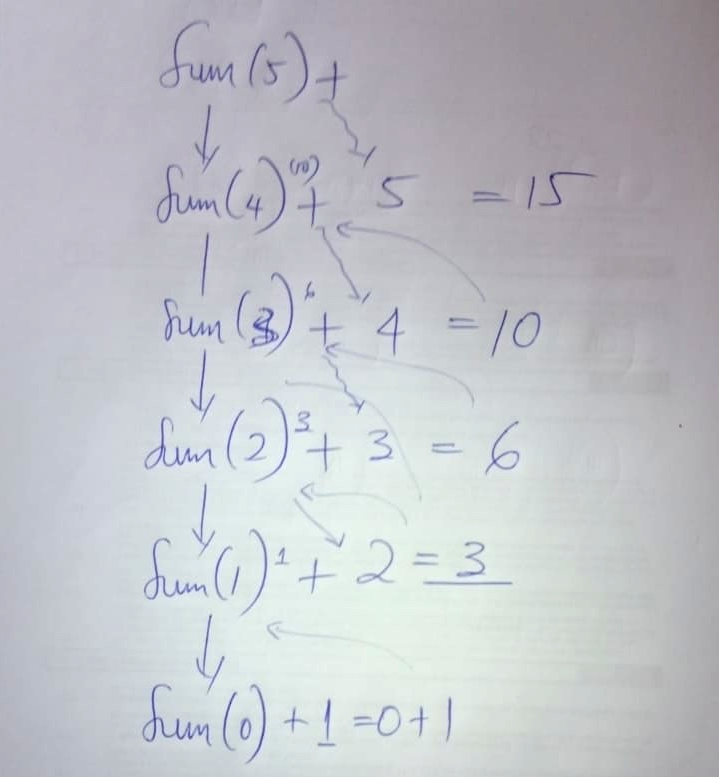

Space/Memory

$O(n)$

Time Taken

$O(n)$

```python
int sum(int n);
```

```python
int sum(int n){
    if (n ==0)
       return 0;
    else
       return sum(n-1)+n;

}
```

```python
int y, x=5;
y =sum(x);
```

```python
cout<<y<<endl;
```

```
15
```

## For Loop/Iterative function

Space/Memory

$O(1)$

Time Taken

$O(n)$

```python
int iSum(int n){
    int i, s = 0;

    for (int i=1; i<=n; i++){
        s = s+ i;
    }
    return s;
}
```

```python
int b=5, k =0;

k = iSum(b);
```

```python
cout<<k<<endl;
```

```
15
```

## Simple Formula

$$n(n+1)\over 2$$

Time is constant

$O(1)$

```python
int v=5, z=0;
z=v*(v+1)/2;
```

```python
cout<<z<<endl;
```

```
15
```